# Optimal Treatment Analysis

## Outcome Variable

**Outcome Variable:** whz

## Predictor Variables

**Intervention Variable:** trth2o

**Adjustment Set:**

- arm
- sex
- W_mage
- meducyrs
- feducyrs
- hhwealth_quart
- hfoodsec
- W_mhtcm
- W_mwtkg
- W_mbmi
- W_nrooms
- W_nhh
- W_nchldlt5
- brthmon
- cleanck
- impfloor
- impsan
- safeh20
- delta_meducyrs
- delta_feducyrs
- delta_hhwealth_quart
- delta_hfoodsec
- delta_W_mhtcm
- delta_W_mwtkg
- delta_W_mbmi
- delta_W_nrooms
- delta_W_nhh
- delta_W_nchldlt5
- delta_brthmon
- delta_cleanck
- delta_impfloor
- delta_impsan
- delta_safeh20

## Stratifying Variables

The analysis was stratified on these variable(s):

- agecat
- studyid
- country

## Data Summary

| agecat | studyid | country | trth2o | n_cell | n |
| --- | --- | --- | --- | --- | --- |
| Birth | ki0047075b-MAL-ED | BANGLADESH | 1 | 110 | 112 |
| Birth | ki0047075b-MAL-ED | BANGLADESH | 0 | 2 | 112 |
| Birth | ki0047075b-MAL-ED | BRAZIL | 1 | 3 | 20 |
| Birth | ki0047075b-MAL-ED | BRAZIL | 0 | 17 | 20 |
| Birth | ki0047075b-MAL-ED | INDIA | 1 | 0 | 1 |
| Birth | ki0047075b-MAL-ED | INDIA | 0 | 1 | 1 |
| Birth | ki0047075b-MAL-ED | NEPAL | 1 | 7 | 9 |
| Birth | ki0047075b-MAL-ED | NEPAL | 0 | 2 | 9 |
| Birth | ki0047075b-MAL-ED | PERU | 1 | 28 | 36 |
| Birth | ki0047075b-MAL-ED | PERU | 0 | 8 | 36 |
| Birth | ki0047075b-MAL-ED | SOUTH AFRICA | 1 | 1 | 5 |
| Birth | ki0047075b-MAL-ED | SOUTH AFRICA | 0 | 4 | 5 |
| Birth | ki0047075b-MAL-ED | TANZANIA, UNITED REPUBLIC OF | 1 | 4 | 21 |
| Birth | ki0047075b-MAL-ED | TANZANIA, UNITED REPUBLIC OF | 0 | 17 | 21 |
| Birth | ki1000108-CMC-V-BCS-2002 | INDIA | 1 | 24 | 24 |
| Birth | ki1000108-CMC-V-BCS-2002 | INDIA | 0 | 0 | 24 |
| Birth | ki1000108-IRC | INDIA | 1 | 105 | 105 |
| Birth | ki1000108-IRC | INDIA | 0 | 0 | 105 |
| Birth | ki1017093b-PROVIDE | BANGLADESH | 1 | 11 | 532 |
| Birth | ki1017093b-PROVIDE | BANGLADESH | 0 | 521 | 532 |
| Birth | ki1017093c-NIH-Crypto | BANGLADESH | 1 | 397 | 707 |
| Birth | ki1017093c-NIH-Crypto | BANGLADESH | 0 | 310 | 707 |
| Birth | ki1113344-GMS-Nepal | NEPAL | 1 | 1 | 4 |
| Birth | ki1113344-GMS-Nepal | NEPAL | 0 | 3 | 4 |
| 6 months | ki0047075b-MAL-ED | BANGLADESH | 1 | 132 | 134 |
| 6 months | ki0047075b-MAL-ED | BANGLADESH | 0 | 2 | 134 |
| 6 months | ki0047075b-MAL-ED | BRAZIL | 1 | 13 | 103 |
| 6 months | ki0047075b-MAL-ED | BRAZIL | 0 | 90 | 103 |
| 6 months | ki0047075b-MAL-ED | INDIA | 1 | 4 | 9 |
| 6 months | ki0047075b-MAL-ED | INDIA | 0 | 5 | 9 |
| 6 months | ki0047075b-MAL-ED | NEPAL | 1 | 69 | 83 |
| 6 months | ki0047075b-MAL-ED | NEPAL | 0 | 14 | 83 |
| 6 months | ki0047075b-MAL-ED | PERU | 1 | 39 | 49 |
| 6 months | ki0047075b-MAL-ED | PERU | 0 | 10 | 49 |
| 6 months | ki0047075b-MAL-ED | SOUTH AFRICA | 1 | 2 | 12 |
| 6 months | ki0047075b-MAL-ED | SOUTH AFRICA | 0 | 10 | 12 |
| 6 months | ki0047075b-MAL-ED | TANZANIA, UNITED REPUBLIC OF | 1 | 6 | 42 |
| 6 months | ki0047075b-MAL-ED | TANZANIA, UNITED REPUBLIC OF | 0 | 36 | 42 |
| 6 months | ki1000108-CMC-V-BCS-2002 | INDIA | 1 | 120 | 120 |
| 6 months | ki1000108-CMC-V-BCS-2002 | INDIA | 0 | 0 | 120 |
| 6 months | ki1000108-IRC | INDIA | 1 | 121 | 121 |
| 6 months | ki1000108-IRC | INDIA | 0 | 0 | 121 |
| 6 months | ki1017093b-PROVIDE | BANGLADESH | 1 | 14 | 603 |
| 6 months | ki1017093b-PROVIDE | BANGLADESH | 0 | 589 | 603 |
| 6 months | ki1017093c-NIH-Crypto | BANGLADESH | 1 | 396 | 715 |
| 6 months | ki1017093c-NIH-Crypto | BANGLADESH | 0 | 319 | 715 |
| 6 months | ki1113344-GMS-Nepal | NEPAL | 1 | 1 | 4 |
| 6 months | ki1113344-GMS-Nepal | NEPAL | 0 | 3 | 4 |
| 24 months | ki0047075b-MAL-ED | BANGLADESH | 1 | 133 | 135 |
| 24 months | ki0047075b-MAL-ED | BANGLADESH | 0 | 2 | 135 |
| 24 months | ki0047075b-MAL-ED | BRAZIL | 1 | 13 | 103 |
| 24 months | ki0047075b-MAL-ED | BRAZIL | 0 | 90 | 103 |
| 24 months | ki0047075b-MAL-ED | INDIA | 1 | 4 | 9 |
| 24 months | ki0047075b-MAL-ED | INDIA | 0 | 5 | 9 |
| 24 months | ki0047075b-MAL-ED | NEPAL | 1 | 69 | 83 |
| 24 months | ki0047075b-MAL-ED | NEPAL | 0 | 14 | 83 |
| 24 months | ki0047075b-MAL-ED | PERU | 1 | 39 | 49 |
| 24 months | ki0047075b-MAL-ED | PERU | 0 | 10 | 49 |
| 24 months | ki0047075b-MAL-ED | SOUTH AFRICA | 1 | 2 | 11 |
| 24 months | ki0047075b-MAL-ED | SOUTH AFRICA | 0 | 9 | 11 |
| 24 months | ki0047075b-MAL-ED | TANZANIA, UNITED REPUBLIC OF | 1 | 6 | 43 |
| 24 months | ki0047075b-MAL-ED | TANZANIA, UNITED REPUBLIC OF | 0 | 37 | 43 |
| 24 months | ki1000108-CMC-V-BCS-2002 | INDIA | 1 | 119 | 119 |
| 24 months | ki1000108-CMC-V-BCS-2002 | INDIA | 0 | 0 | 119 |
| 24 months | ki1000108-IRC | INDIA | 1 | 121 | 121 |
| 24 months | ki1000108-IRC | INDIA | 0 | 0 | 121 |
| 24 months | ki1017093b-PROVIDE | BANGLADESH | 1 | 14 | 579 |
| 24 months | ki1017093b-PROVIDE | BANGLADESH | 0 | 565 | 579 |
| 24 months | ki1017093c-NIH-Crypto | BANGLADESH | 1 | 242 | 514 |
| 24 months | ki1017093c-NIH-Crypto | BANGLADESH | 0 | 272 | 514 |
| 24 months | ki1113344-GMS-Nepal | NEPAL | 1 | 1 | 4 |
| 24 months | ki1113344-GMS-Nepal | NEPAL | 0 | 3 | 4 |

The following strata were considered:

- agecat: 24 months, studyid: ki0047075b-MAL-ED, country: BANGLADESH
- agecat: 24 months, studyid: ki0047075b-MAL-ED, country: BRAZIL
- agecat: 24 months, studyid: ki0047075b-MAL-ED, country: INDIA
- agecat: 24 months, studyid: ki0047075b-MAL-ED, country: NEPAL
- agecat: 24 months, studyid: ki0047075b-MAL-ED, country: PERU
- agecat: 24 months, studyid: ki0047075b-MAL-ED, country: SOUTH AFRICA
- agecat: 24 months, studyid: ki0047075b-MAL-ED, country: TANZANIA, UNITED REPUBLIC OF
- agecat: 24 months, studyid: ki1000108-CMC-V-BCS-2002, country: INDIA
- agecat: 24 months, studyid: ki1000108-IRC, country: INDIA
- agecat: 24 months, studyid: ki1017093b-PROVIDE, country: BANGLADESH
- agecat: 24 months, studyid: ki1017093c-NIH-Crypto, country: BANGLADESH
- agecat: 24 months, studyid: ki1113344-GMS-Nepal, country: NEPAL
- agecat: 6 months, studyid: ki0047075b-MAL-ED, country: BANGLADESH
- agecat: 6 months, studyid: ki0047075b-MAL-ED, country: BRAZIL
- agecat: 6 months, studyid: ki0047075b-MAL-ED, country: INDIA
- agecat: 6 months, studyid: ki0047075b-MAL-ED, country: NEPAL
- agecat: 6 months, studyid: ki0047075b-MAL-ED, country: PERU
- agecat: 6 months, studyid: ki0047075b-MAL-ED, country: SOUTH AFRICA
- agecat: 6 months, studyid: ki0047075b-MAL-ED, country: TANZANIA, UNITED REPUBLIC OF
- agecat: 6 months, studyid: ki1000108-CMC-V-BCS-2002, country: INDIA
- agecat: 6 months, studyid: ki1000108-IRC, country: INDIA
- agecat: 6 months, studyid: ki1017093b-PROVIDE, country: BANGLADESH
- agecat: 6 months, studyid: ki1017093c-NIH-Crypto, country: BANGLADESH
- agecat: 6 months, studyid: ki1113344-GMS-Nepal, country: NEPAL
- agecat: Birth, studyid: ki0047075b-MAL-ED, country: BANGLADESH
- agecat: Birth, studyid: ki0047075b-MAL-ED, country: BRAZIL
- agecat: Birth, studyid: ki0047075b-MAL-ED, country: INDIA
- agecat: Birth, studyid: ki0047075b-MAL-ED, country: NEPAL
- agecat: Birth, studyid: ki0047075b-MAL-ED, country: PERU
- agecat: Birth, studyid: ki0047075b-MAL-ED, country: SOUTH AFRICA
- agecat: Birth, studyid: ki0047075b-MAL-ED, country: TANZANIA, UNITED REPUBLIC OF
- agecat: Birth, studyid: ki1000108-CMC-V-BCS-2002, country: INDIA
- agecat: Birth, studyid: ki1000108-IRC, country: INDIA
- agecat: Birth, studyid: ki1017093b-PROVIDE, country: BANGLADESH
- agecat: Birth, studyid: ki1017093c-NIH-Crypto, country: BANGLADESH
- agecat: Birth, studyid: ki1113344-GMS-Nepal, country: NEPAL

### Dropped Strata

Some strata were dropped due to rare outcomes:

- agecat: Birth, studyid: ki0047075b-MAL-ED, country: BANGLADESH
- agecat: Birth, studyid: ki0047075b-MAL-ED, country: BRAZIL
- agecat: Birth, studyid: ki0047075b-MAL-ED, country: INDIA
- agecat: Birth, studyid: ki0047075b-MAL-ED, country: NEPAL
- agecat: Birth, studyid: ki0047075b-MAL-ED, country: SOUTH AFRICA
- agecat: Birth, studyid: ki0047075b-MAL-ED, country: TANZANIA, UNITED REPUBLIC OF
- agecat: Birth, studyid: ki1000108-CMC-V-BCS-2002, country: INDIA
- agecat: Birth, studyid: ki1000108-IRC, country: INDIA
- agecat: Birth, studyid: ki1113344-GMS-Nepal, country: NEPAL
- agecat: 6 months, studyid: ki0047075b-MAL-ED, country: BANGLADESH
- agecat: 6 months, studyid: ki0047075b-MAL-ED, country: INDIA
- agecat: 6 months, studyid: ki0047075b-MAL-ED, country: SOUTH AFRICA
- agecat: 6 months, studyid: ki1000108-CMC-V-BCS-2002, country: INDIA
- agecat: 6 months, studyid: ki1000108-IRC, country: INDIA
- agecat: 6 months, studyid: ki1113344-GMS-Nepal, country: NEPAL
- agecat: 24 months, studyid: ki0047075b-MAL-ED, country: BANGLADESH
- agecat: 24 months, studyid: ki0047075b-MAL-ED, country: INDIA
- agecat: 24 months, studyid: ki0047075b-MAL-ED, country: SOUTH AFRICA
- agecat: 24 months, studyid: ki1000108-CMC-V-BCS-2002, country: INDIA
- agecat: 24 months, studyid: ki1000108-IRC, country: INDIA
- agecat: 24 months, studyid: ki1113344-GMS-Nepal, country: NEPAL

## Methods Detail

We’re interested in the causal parameters $E[Y_a]$ for all values of $a \in \mathcal{A}$. These parameters represent the mean outcome if, possibly contrary to fact, we intervened to set all units to have $A=a$. Under the randomization and positivity assumptions, these are identified by the statistical parameters $\psi_a=E_W[E_{Y|A,W}(Y|A=a,W)]$. In addition, we’re interested in the mean of $Y$, $E[Y]$ under no intervention (the observed mean). We will estimate these parameters by using SuperLearner to fit the relevant likelihood factors – $E_{Y|A,W}(Y|A=a,W)$ and $p(A=a|W)$, and then updating our likelihood fit using a joint TMLE.

For unadjusted analyses ($W=\{\}$), initial likelihoods were estimated using Lrnr_glm to estimate the simple $E(Y|A)$ and Lrnr_mean to estimate $p(A)$. For adjusted analyses, a small library containing Lrnr_glmnet, Lrnr_xgboost, and Lrnr_mean was used.

# Results Detail

## Results Plots

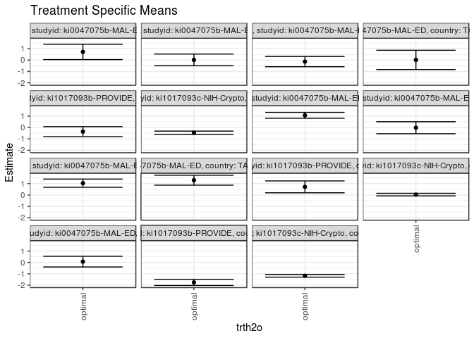

## Results Table

### Parameter: TSM

| agecat | studyid | country | intervention_level | baseline_level | estimate | ci_lower | ci_upper |
| --- | --- | --- | --- | --- | --- | --- | --- |
| Birth | ki0047075b-MAL-ED | PERU | optimal | observed | 0.0712630 | -0.3984515 | 0.5409774 |
| Birth | ki1017093b-PROVIDE | BANGLADESH | optimal | observed | -1.7552691 | -2.0281591 | -1.4823792 |
| Birth | ki1017093c-NIH-Crypto | BANGLADESH | optimal | observed | -1.1719590 | -1.2917695 | -1.0521485 |
| 6 months | ki0047075b-MAL-ED | BRAZIL | optimal | observed | 1.0741754 | 0.8138233 | 1.3345275 |
| 6 months | ki0047075b-MAL-ED | NEPAL | optimal | observed | -0.0161819 | -0.5436804 | 0.5113167 |
| 6 months | ki0047075b-MAL-ED | PERU | optimal | observed | 1.0392361 | 0.6778737 | 1.4005985 |
| 6 months | ki0047075b-MAL-ED | TANZANIA, UNITED REPUBLIC OF | optimal | observed | 1.2993623 | 0.8644276 | 1.7342971 |
| 6 months | ki1017093b-PROVIDE | BANGLADESH | optimal | observed | 0.7149814 | 0.1931310 | 1.2368317 |
| 6 months | ki1017093c-NIH-Crypto | BANGLADESH | optimal | observed | 0.0346613 | -0.0792692 | 0.1485919 |
| 24 months | ki0047075b-MAL-ED | BRAZIL | optimal | observed | 0.7200321 | 0.0450530 | 1.3950112 |
| 24 months | ki0047075b-MAL-ED | NEPAL | optimal | observed | 0.0149490 | -0.5008348 | 0.5307328 |
| 24 months | ki0047075b-MAL-ED | PERU | optimal | observed | -0.1326100 | -0.5858197 | 0.3205996 |
| 24 months | ki0047075b-MAL-ED | TANZANIA, UNITED REPUBLIC OF | optimal | observed | 0.0172939 | -0.8306882 | 0.8652760 |
| 24 months | ki1017093b-PROVIDE | BANGLADESH | optimal | observed | -0.3596890 | -0.7999885 | 0.0806105 |
| 24 months | ki1017093c-NIH-Crypto | BANGLADESH | optimal | observed | -0.4590149 | -0.6029050 | -0.3151248 |

### Parameter: E(Y)

| agecat | studyid | country | intervention_level | baseline_level | estimate | ci_lower | ci_upper |
| --- | --- | --- | --- | --- | --- | --- | --- |
| Birth | ki0047075b-MAL-ED | PERU | observed | observed | -0.1791667 | -0.4729428 | 0.1146094 |
| Birth | ki1017093b-PROVIDE | BANGLADESH | observed | observed | -1.2984586 | -1.3752758 | -1.2216415 |
| Birth | ki1017093c-NIH-Crypto | BANGLADESH | observed | observed | -1.2441513 | -1.3281130 | -1.1601897 |
| 6 months | ki0047075b-MAL-ED | BRAZIL | observed | observed | 0.9731715 | 0.7347562 | 1.2115869 |
| 6 months | ki0047075b-MAL-ED | NEPAL | observed | observed | 0.1447189 | -0.1029021 | 0.3923399 |
| 6 months | ki0047075b-MAL-ED | PERU | observed | observed | 0.9109184 | 0.5934529 | 1.2283839 |
| 6 months | ki0047075b-MAL-ED | TANZANIA, UNITED REPUBLIC OF | observed | observed | 0.7418651 | 0.4248303 | 1.0588998 |
| 6 months | ki1017093b-PROVIDE | BANGLADESH | observed | observed | -0.1990907 | -0.2817968 | -0.1163845 |
| 6 months | ki1017093c-NIH-Crypto | BANGLADESH | observed | observed | 0.0297622 | -0.0491685 | 0.1086930 |
| 24 months | ki0047075b-MAL-ED | BRAZIL | observed | observed | 0.5203560 | 0.2632846 | 0.7774274 |
| 24 months | ki0047075b-MAL-ED | NEPAL | observed | observed | -0.2262651 | -0.4277663 | -0.0247638 |
| 24 months | ki0047075b-MAL-ED | PERU | observed | observed | 0.1148299 | -0.1831101 | 0.4127700 |
| 24 months | ki0047075b-MAL-ED | TANZANIA, UNITED REPUBLIC OF | observed | observed | 0.1037209 | -0.1942394 | 0.4016813 |
| 24 months | ki1017093b-PROVIDE | BANGLADESH | observed | observed | -0.8928670 | -0.9755153 | -0.8102187 |
| 24 months | ki1017093c-NIH-Crypto | BANGLADESH | observed | observed | -0.6103502 | -0.7050157 | -0.5156847 |

### Parameter: PAR

| agecat | studyid | country | intervention_level | baseline_level | estimate | ci_lower | ci_upper |
| --- | --- | --- | --- | --- | --- | --- | --- |
| Birth | ki0047075b-MAL-ED | PERU | optimal | observed | -0.2504296 | -0.7273669 | 0.2265076 |
| Birth | ki1017093b-PROVIDE | BANGLADESH | optimal | observed | 0.4568105 | 0.1884130 | 0.7252080 |
| Birth | ki1017093c-NIH-Crypto | BANGLADESH | optimal | observed | -0.0721924 | -0.1560427 | 0.0116580 |
| 6 months | ki0047075b-MAL-ED | BRAZIL | optimal | observed | -0.1010039 | -0.2042817 | 0.0022739 |
| 6 months | ki0047075b-MAL-ED | NEPAL | optimal | observed | 0.1609007 | -0.3225664 | 0.6443679 |
| 6 months | ki0047075b-MAL-ED | PERU | optimal | observed | -0.1283178 | -0.2933556 | 0.0367201 |
| 6 months | ki0047075b-MAL-ED | TANZANIA, UNITED REPUBLIC OF | optimal | observed | -0.5574973 | -1.0589796 | -0.0560150 |
| 6 months | ki1017093b-PROVIDE | BANGLADESH | optimal | observed | -0.9140720 | -1.4298375 | -0.3983066 |
| 6 months | ki1017093c-NIH-Crypto | BANGLADESH | optimal | observed | -0.0048991 | -0.0845455 | 0.0747473 |
| 24 months | ki0047075b-MAL-ED | BRAZIL | optimal | observed | -0.1996761 | -0.7951897 | 0.3958376 |
| 24 months | ki0047075b-MAL-ED | NEPAL | optimal | observed | -0.2412140 | -0.7061565 | 0.2237285 |
| 24 months | ki0047075b-MAL-ED | PERU | optimal | observed | 0.2474400 | -0.1076761 | 0.6025561 |
| 24 months | ki0047075b-MAL-ED | TANZANIA, UNITED REPUBLIC OF | optimal | observed | 0.0864270 | -0.7190722 | 0.8919263 |
| 24 months | ki1017093b-PROVIDE | BANGLADESH | optimal | observed | -0.5331780 | -0.9712867 | -0.0950693 |
| 24 months | ki1017093c-NIH-Crypto | BANGLADESH | optimal | observed | -0.1513353 | -0.2455835 | -0.0570871 |